# Reproducible report on Shark Control Program Catch Statistics

Project 2

Student(s) SID: 460437466, 470378281, 440126393

Lab W16A Group 3 | Thursday & Friday | 4-6 pm | Carslaw Computer Lab 610

# 1 Executive Summary

The report first provides an initial data analysis on the Shark Control Program Catch Statistics. The dataset was retrieved from the Agriculture and Fisheries Department under Queensland Government. Government approved statistics ensures that the data is reliable and precise.

Two research questions were then investigated, focusing on discovering correlations between the water temperature and the location, and the correlation between length of tiger sharks and the water temperature.

Main discoveries include identifying locations in which sharks appear in the largest and hottest water temperature ranges, and no evidence of linear correlation between length of tiger sharks and water temperature.

# 2 Full Report

## 2.1 Initial Data Analysis (IDA)

```r
# Calling CSV file "sharks"
sharks = read.csv("sharks.csv")

# Quick look at top 5 rows of data
head(sharks)
```

```
##   X         Species.Name       Date   Area            Location  Latitude
## 1 1  AUSTRALIAN BLACKTIP 16/11/2016 Cairns     Holloways Beach -16°49.82
## 2 2 BLACKTIP REEF WHALER   2/1/2016 Cairns Buchans Point Beach -16°43.56
## 3 3 BLACKTIP REEF WHALER   2/1/2016 Cairns         Ellis Beach  -16°43.3
## 4 4 BLACKTIP REEF WHALER   5/1/2016 Mackay       Harbour Beach  -21°7.08
## 5 5 BLACKTIP REEF WHALER   7/1/2016 Mackay       Harbour Beach   -21°7.1
## 6 6 BLACKTIP REEF WHALER  13/1/2016 Cairns     Holloways Beach -16°49.89
##   Longitude Length..m. Water.Temp..C.    Month Day.of.Week
## 1 145°44.85        1.0             27 November   Wednesday
## 2 145°39.78        0.7             27  January    Saturday
## 3 145°39.01        1.5             27  January    Saturday
## 4 149°13.62        2.2             26  January     Tuesday
## 5 149°13.68        1.7             26  January    Thursday
## 6 145°44.91        1.2             29  January   Wednesday
```

```r
## Size of data
dim(sharks)
```

```
## [1] 543  11
```

According to the given dataset, there are 11 irrelevant entries (N/A) are presented ranging from row 533 to 543.

```r
## R's classification of data
class(sharks)
```

```
## [1] "data.frame"
```

```r
## R's classification of variables
str(sharks)
```

```
## 'data.frame':    543 obs. of  11 variables:
##  $ X             : int  1 2 3 4 5 6 7 8 9 10 ...
##  $ Species.Name  : Factor w/ 24 levels "AUSTRALIAN BLACKTIP",..: 1 2 2 2 2 2 2 2 2 2 ...
##  $ Date          : Factor w/ 243 levels "1/1/2016","1/10/2016",..: 53 83 83 204 221 31 92 47 109 87 ...
##  $ Area          : Factor w/ 11 levels "Bundaberg","Cairns",..: 2 2 2 6 6 2 2 11 2 2 ...
##  $ Location      : Factor w/ 63 levels "Alexandra Headland",..: 25 9 19 24 24 25 48 2 13 62 ...
##  $ Latitude      : Factor w/ 202 levels "-16°43.21","-16°43.23",..: 17 6 4 77 78 18 9 60 12 14 ...
##  $ Longitude     : Factor w/ 186 levels "145°38.85","145°38.91",..: 17 6 4 66 70 18 9 48 12 14 ...
##  $ Length..m.    : num  1 0.7 1.5 2.2 1.7 1.2 0.75 1.2 0.8 1.3 ...
##  $ Water.Temp..C.: int  27 27 27 26 26 29 30 31 29 29 ...
##  $ Month         : Factor w/ 12 levels "April","August",..: 10 5 5 5 5 5 5 4 8 1 ...
##  $ Day.of.Week   : Factor w/ 7 levels "Friday","Monday",..: 7 3 3 6 5 7 7 2 6 3 ...
```

```r
sapply(sharks, class)
```

```
##              X   Species.Name           Date           Area       Location
##      "integer"       "factor"       "factor"       "factor"       "factor"
##       Latitude      Longitude     Length..m. Water.Temp..C.          Month
##       "factor"       "factor"      "numeric"      "integer"       "factor"
##    Day.of.Week
##       "factor"
```

Background

Dataset retrieved from the Queensland Goverment shark control program (https://www.data.qld.gov.au/dataset/shark-control-program-shark-catch-statistics/resource/5c6be990-3938-4125-8cca-dac0cd734263)

Dataset is accurate and reliable as it originates from the Queenslands government website. The dataset was created by the SHARK CONTROL PROGRAM for better understanding of various species of sharks and public safety.

Possible limitations would be that there were no general ideas on what specific data were needed to validate their hypothesis. A target was set by the research team and the data were moulded around it.

Variables

Qualitative :

- Nominal Data: Species name, location
- Ordinal Data: Date, Day of week

Quantative :

- Continuous Data: Water Temp(C), longitude and latitude
- Discrete Data: Length(m), Month

The rows respresents the species name of the shark caught and other relevant data recorded. The columns represents the measured variables i.e.Date, Species name, Water temp(C),etc. However, the ‘X’ variable appears in the output is not part of the dataset that is needed to assess, it is simply just a row numbers generated in CSV file.

Stakeholders

Since public safety is directly affected by the amount of shark activties around the beaches, possible stakeholders would be the lifeguards stationed at those specified beaches, surfers who often surf at those specified beaches as stated in dataset, and marine biologists who are interested in researching on various species of sharks and their behaviour such as migrations during certain period and water temperatures.

Assesement

Since the data is recorded and created under the observation of the Queensland Government, the data would be credible and reliable. Some limitations to the data would be missing out on the gender of the shark species where it might be crucial to determine the shark activities at recorded locations. For example, during mating seasons, more sharks of certain species would can be found at certain locations at a higher frequency as comapared to other shark species. Also, there are 2 ‘unknown’ sharks entries presented in the dataset, which might give less insight compared to other entries as it fails to categorise the species of sharks spotted.

## 2.2 Research Question 1

Question

Is there a relation between desired water temperature and location of sharks?

Summaries

We first investigate the quantitative variable, water temperature, by looking at the summary statistics.

```r
# Graphical and/or numerical summaries
## Summary statistics of water temp only
summary(sharks$Water.Temp..C.)
```

```
##    Min. 1st Qu.  Median    Mean 3rd Qu.    Max.    NA's
##   17.00   23.00   25.00   24.83   27.00   32.00      11
```

The average mean temperature is 24.83°C.

We then investigate the qualitative variable, location of sharks spotted, by a numerical summary in frequency table.

```r
## Frequency table showing of sharks perr location recorded
## Table is sorted in increasing order
locationT = sort(table(sharks$Location), increasing = T)
locationT
```

```
##
##          Bribie Island          Buddina Beach              Cooee Bay
##                      1                      1                      1
##   Hyatt Regency Resort          Kurrawa Beach            Nobby Beach
##                      1                      1                      1
##   North Burleigh Beach         Peregian Beach       Point Cartwright
##                      1                      1                      1
## Surfers Paradise Beach              Caloundra             Main Beach
##                      1                      2                      2
##          Mermaid Beach       Mooloolaba Beach                Bargara
##                      2                      2                      3
##           Blacks Beach            Eimeo Beach            Kirra Beach
##                      3                      3                      3
##          Sunrise Beach         Sunshine Beach     Tallebudgera Beach
##                      3                      3                      3
##             Broadbeach    Buchans Point Beach         Burleigh Beach
##                      4                      4                      4
##      Coolangatta Beach      Farnborough Beach             Kemp Beach
##                      4                      4                      4
##     Maroochydore Beach            Miami Beach         Mulambin Beach
##                      4                      4                      4
##     Alexandra Headland         Cylinder Beach       Lammermoor Beach
##                      5                      5                      5
##         Marcoola Beach            Ocean Beach              Palm Cove
##                      5                      5                      5
##             Picnic Bay            Rainbow Bay                Yeppoon
##                      5                      5                      5
##          Bilinga Beach          Bucasia Beach          Clifton Beach
##                      6                      6                      6
##        Currumbin Beach       Fishermans Beach             The Strand
##                      6                      7                      7
##            Tanby Point          Trinity Beach       Pallarenda Beach
##                      8                      8                      9
##        Holloways Beach               Alma Bay         Lamberts Beach
##                     10                     13                     13
##              Nelly Bay           Florence Bay               Emu Park
##                     13                     16                     17
##            Radical Bay            Ellis Beach                  Noosa
##                     17                     18                     22
##           Neilson Park           Kellys Beach          Horseshoe Bay
##                     23                     26                     32
##          Rainbow Beach          Harbour Beach           Tannum Sands
##                     36                     41                     52
```

Tannum Sands has the highest number of sharks with 52 entries.

Comparative boxplots describe the relationship between these variables:

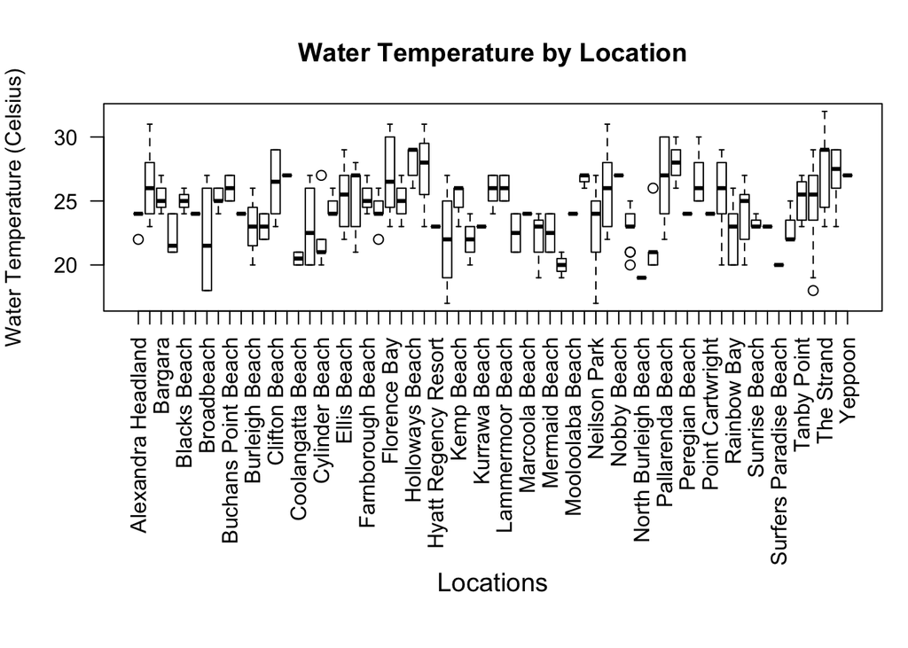

```r
## Comparative boxplot showing water temperature where sharks are spotted by location
par(mar = c(13,4,4,1)) #bottom, left, top, right margin
boxplot(sharks$Water.Temp..C. ~ sharks$Location, main = "Water Temperature by Location", ylab = "Water Temperature (Celsius)", xlab = " ", las = 2)
title(xlab = "Locations", line = 10, cex.lab = 1.2)
```

The box plot and the quantile statistics below shows 50% of sharks prefer water temperatures of 23-27°C.

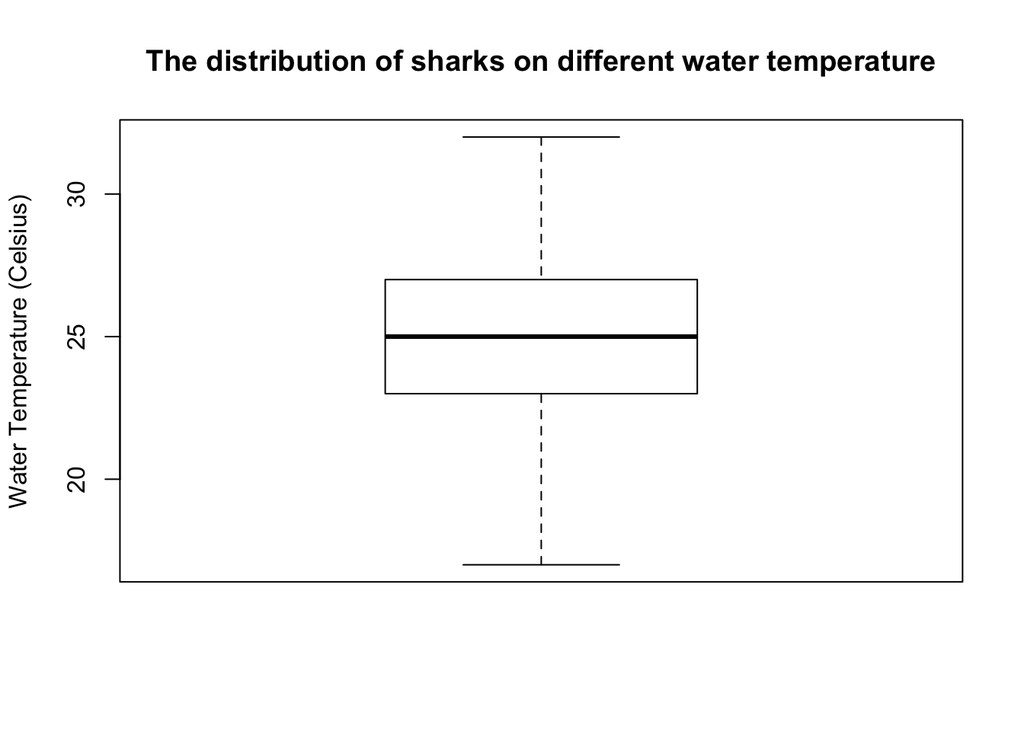

```r
## Boxplot showing Distribution of sharks on different water temp
boxplot(sharks$Water.Temp..C., ylab = "Water Temperature (Celsius)", main = "The distribution of sharks on different water temperature")
```

```r
## Numerical summary of IQR for water temperatures
quantile(as.numeric(sharks$Water.Temp..C.), probs = c(.0, .25, .5, .75, 1), na.rm = TRUE)
```

```
##   0%  25%  50%  75% 100%
##   17   23   25   27   32
```

Explanation

Sharks recorded in this assessment proves that water temperature along with location can be an accurate gage of preference. For research we can selectively demonstrate that half the population prefer water of 23°C and 27°C. From there you can select specific species of sharks. They will either be in that range of 23-27°C or out of the range.

There are many other factors in the sharks population which can change their prefered location. Open water tides and beaches connected to the open ocean are proven to have greater traffic due to the ease of access sharks have from swimming from smaller beaches. Availability of specific food source, human interference such as fishing causes sharks to roam and change their desired location, global warming and many other factors determine whether sharks are found in a certain location and thus water temperature.

Further Research

Tiger sharks have been readily researched and tracked throughout Australian waters especially in the East. The studies show that tiger sharks have been known to alternate between localise and extensive movements that may encompass a variety of habitats (Holmes et al., 2014). Specific movement paths on the Australian East coast were most often associated with the 200m shelf-edge isobath or mid-continental shelf areas, with infrequent visits to nearshore waters. Sharks used shelf-edge isobath or underwater seamounts as a guide, particularly during broad scale migration (Holmes et al., 2014).

Withdrawal from pleasant NSW waters into subtropical QLD waters occured when water temperatures drop below 19°C (July-September). Despite a seemingly clear correlation with water temperature, there are other extrinsic factors that may influence shark movements, such as prey availability. Stronger EAC (East Atlantic) currents flowing Southward during the warmer months mark a seasonal biome shift in this region, which influences the distribution of pelagic fishes such as tunas, kingfish, mackerels, and billfishes undoubtedly attracting the tiger sharks to these certain areas (Holmes et al., 2014). Definitely a combination of both location and water temperature along with other factors contribute to tiger sharks’ choice of location.

## 2.3 Research Question 2

Question

Is there a correlation between the length of the tiger sharks and water temperature at which they were spotted?

Summaries and Explanation

According to National Geographic, tiger sharks are the world’s most dangerous shark species after the great white shark. The given dataset consists of more than 1/3 entries (207 out of 532 valid entries) under the “Tiger Shark” category. Therefore we have chosen this as a notable subset of interest to investigate on.

The frequency table and bar plot below shows the number of sharks per species recorded, arranged in ascending order.

There are 207 tiger shark entries in total, which is the species with the highest number of sharks recorded in this dataset.

```r
# Graphical and/or numerical summaries
## Frequency table showing number of sharks per species recorded
## Table is sorted in increasing order
t = sort(table(sharks$Species.Name),increasing = T)
t
```

```
##
##    AUSTRALIAN BLACKTIP           CREEK WHALER        GRACEFUL WHALER
##                      1                      1                      1
##       GREY NURSE SHARK         SLIT EYE SHARK            ZEBRA SHARK
##                      1                      1                      1
##          UNKNOWN SHARK             MILK SHARK           DUSKY WHALER
##                      2                      3                      4
##                   MAKO         SANDBAR WHALER       SHARPTOOTH SHARK
##                      5                      5                      5
##        HARDNOSE WHALER            WHITE SHARK          PIGEYE WHALER
##                      6                      6                     14
##   SCALLOPED HAMMERHEAD   BLACKTIP REEF WHALER       GREAT HAMMERHEAD
##                     16                     20                     22
##       SPOT-TAIL WHALER            TAWNY SHARK       LONG NOSE WHALER
##                     22                     23                     36
## COMMON BLACKTIP WHALER            BULL WHALER            TIGER SHARK
##                     39                     91                    207
```

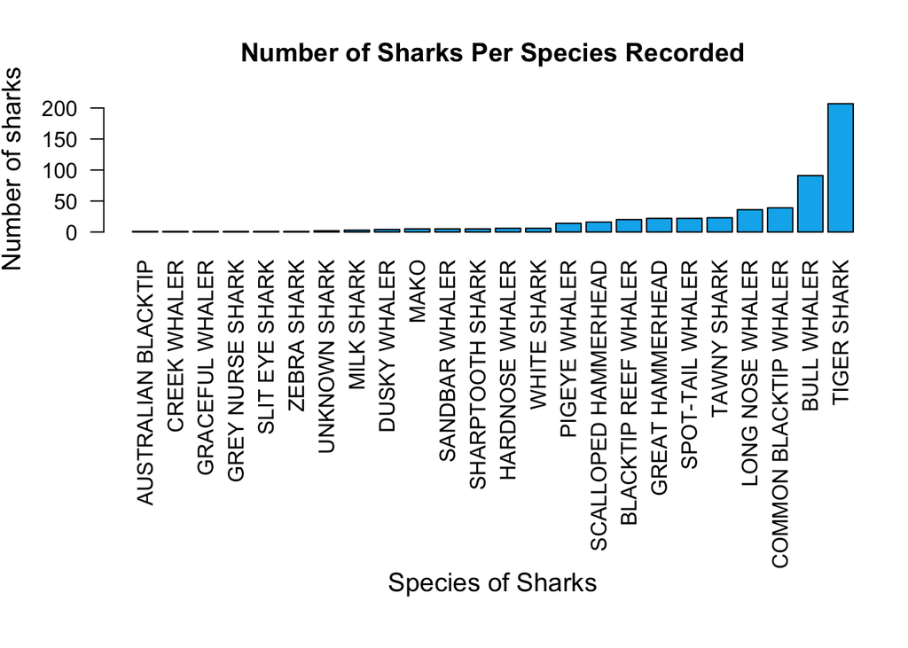

```r
## Single barplot showing number of sharks per species recorded
par(mar = c(16,4,4,1))
barplot(t, xlab = "", ylab = "Number of sharks", main = "Number of Sharks Per Species Recorded", las = 2, cex.main = 1.2, cex.lab = 1.2, cex.axis = 1, col = "deepskyblue2")
title(xlab = "Species of Sharks", line = 13, cex.lab = 1.2)
```

To begin our investigation, we have extracted a subset consisting of only entries relating to tiger sharks from the larger dataset.

```r
# extracting subset of Tiger Sharks entries
tiger = subset(sharks, Species.Name == 'TIGER SHARK')

# Dimensions of subset- 207 rows and 11 columns
dim(tiger)
```

```
## [1] 207  11
```

The following are numerical summaries of water temperature and length of tiger sharks spotted. 50% of tiger sharks are spotted in water temperature ranging from 23 to 27 degree Celsius, with median at 25 degree Celsius. 50% of tiger sharks have length 1.95 to 3.12 metres, with median of 2.37 metres.

```r
# summery statistics showing distribution of data
summary(tiger$Water.Temp..C.)
```

```
##    Min. 1st Qu.  Median    Mean 3rd Qu.    Max.
##   17.00   23.00   25.00   24.87   27.00   31.00
```

```r
summary(tiger$Length..m.)
```

```
##    Min. 1st Qu.  Median    Mean 3rd Qu.    Max.
##   0.700   1.950   2.370   2.459   3.120   4.100
```

We use a scatter plot as graphical summary to consider the relation between the two quantitative variables. A point of average is plotted on the graph to indicate the centre.

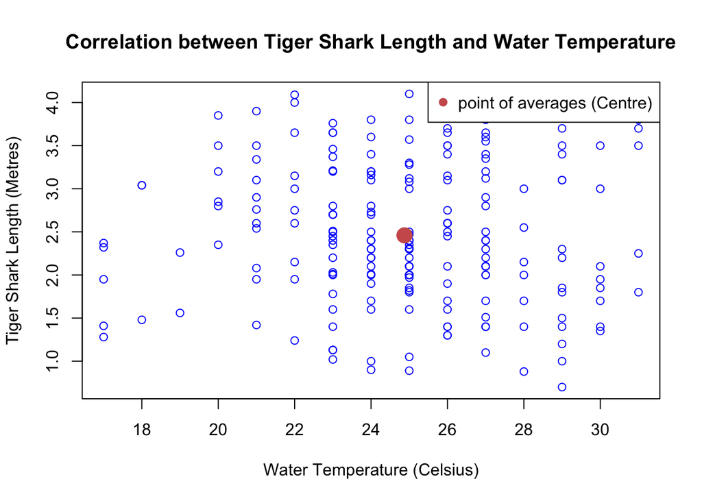

```r
# Scatter plot showing relation between tiger shark length and water temp
plot(tiger$Water.Temp..C., tiger$Length..m., main = "Correlation between Tiger Shark Length and Water Temperature", xlab = "Water Temperature (Celsius)", ylab = "Tiger Shark Length (Metres)", col = "blue")

# Point of average (Centre)
points(mean(tiger$Water.Temp..C.), mean(tiger$Length..m.), col = "indianred", pch = 19, cex = 2)
legend("topright", c("point of averages (Centre)"), col = "indianred", pch = 19)
```

Statistical methods

We have chosen linear regression line as our statistical method to assess whether there is a correlation between the two quantitative variables.

The correlation coefficient is given by the following:

```r
# Linear regression
## Correlation coefficient
cor(tiger$Water.Temp..C., tiger$Length..m.)
```

```
## [1] -0.04737141
```

A negative correlation indicates that as water temperature increases, the length of the tiger sharks spotted decreases. However -0.047 is very far away from -1 and 1, showing no evidence of a linear relationship, hence the two variables are not correlated.

The scatter plot and regression line below is a graphical summary of the relation between tiger shark lengths and water temperatures. The data points are not clustered tightly around the regression line indicating a very weak association.

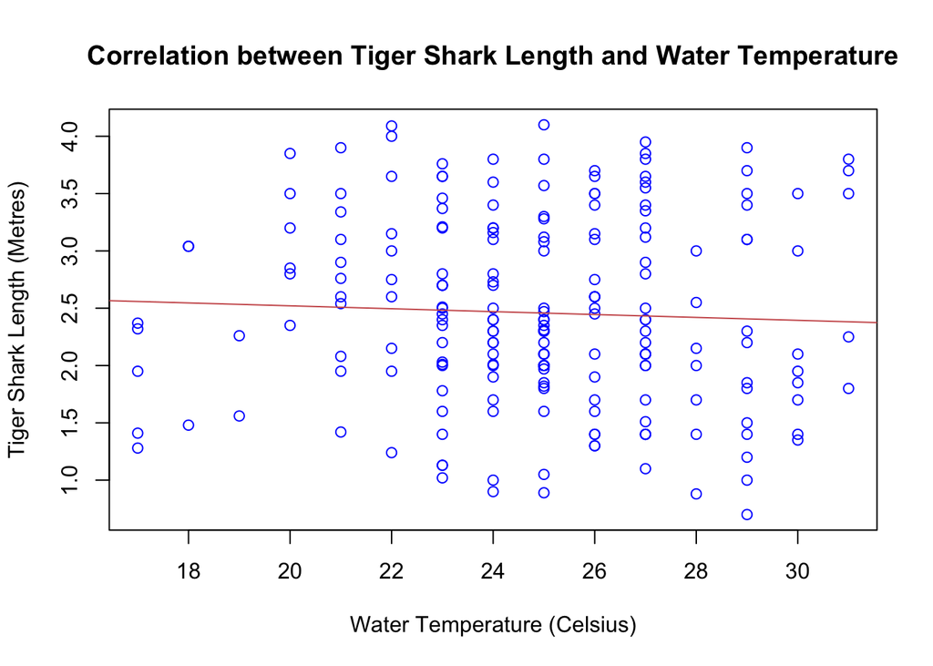

```r
## Scatter plot with regression line
plot(tiger$Water.Temp..C., tiger$Length..m., main = "Correlation between Tiger Shark Length and Water Temperature", xlab = "Water Temperature (Celsius)", ylab = "Tiger Shark Length (Metres)", col = "blue")
L = lm(tiger$Length..m. ~ tiger$Water.Temp..C.)
abline(L, col = "indianred")
```

A summary of the linear model is provided below, providing model parameters to indicate how good the model is.

```r
## Summary of the liear model
summary(L)
```

```
##
## Call:
## lm(formula = tiger$Length..m. ~ tiger$Water.Temp..C.)
##
## Residuals:
##     Min      1Q  Median      3Q     Max
## -1.7071 -0.5456 -0.1071  0.6831  1.6421
##
## Coefficients:
##                      Estimate Std. Error t value Pr(>|t|)
## (Intercept)           2.77492    0.46799   5.929 1.27e-08 ***
## tiger$Water.Temp..C. -0.01268    0.01868  -0.679    0.498
## ---
## Signif. codes:  0 '***' 0.001 '**' 0.01 '*' 0.05 '.' 0.1 ' ' 1
##
## Residual standard error: 0.8134 on 205 degrees of freedom
## Multiple R-squared:  0.002244,   Adjusted R-squared:  -0.002623
## F-statistic: 0.4611 on 1 and 205 DF,  p-value: 0.4979
```

Conclusion

Our investigation shows that the length of tiger sharks and the water temperature they were spotted shows no linear relationship and are not correlated, as concluded from a very small and weak correlation coefficient and corresponding linear regression line from the linear model.

# 3 References

The State of Queensland; Agriculture and Fisheries. (n.d.). Shark Control Program Shark Catch Statistics by year - 2001-2016- Shark Control Program catch statistics - open Data Portal: Queensland Government. Retrieved from https://www.data.qld.gov.au/dataset/shark-control-shark-catch-statistics/resource/5c6be990-3938-4125-8cca-dac0cd734263

Holmes, B. J., Pepperell, J. G., Griffiths, S. P., Jaine, F. R. A., Tibbetts, I. R., & Bennett, M. B. (2014). Tiger shark (Galeocerdo cuvier) movement patterns and habitat use determined by satellite tagging in eastern Australian waters. Marine Biology, 161(11), 2645–2658. doi: 10.1007/s00227-014-2536-1 Retrieved from https://link.springer.com/article/10.1007/s00227-014-2536-1

Tiger Shark.(2018, September 21). Retrieved from https://www.nationalgeographic.com/animals/fish/t/tiger-shark/